# SOL BDA

Kyle MacDonald

June 19, 2015

## SOL Experiment

- 29 kids complete ASL version of the LWL task (Fernald et al., 1998). Each kid is given 32 2-AFC trials. We want to analyze the relations between RT and age/productive ASL vocabulary.
- But RTs are only meaningful if they are generated by the underlying process of interest: speed of lexcial access. Put another way, you can be fast (or slow) in the VLP task for the wrong reasons, because you are just guessing.
- So we want some way to flag participants that we think are likely to be guessing on our task.

## Data structure

| Sub.Num | age_cdi_months | signs_produced | C_T_count | total_trials_shifting | mean_correct_rt | C_T_prop |
| --- | --- | --- | --- | --- | --- | --- |
| 30009 | 40 | 81 | 16 | 22 | 1028.571 | 0.73 |
| 30010 | 44 | 77 | 19 | 25 | 1187.000 | 0.76 |
| 30011 | 16 | 19 | 3 | 4 | 1633.000 | 0.75 |
| 30013 | 31 | 81 | 9 | 9 | 1140.000 | 1.00 |
| 30014 | 33 | 80 | 10 | 13 | 1283.300 | 0.77 |
| 30015 | 21 | 41 | 6 | 8 | 1258.250 | 0.75 |

## Visualize

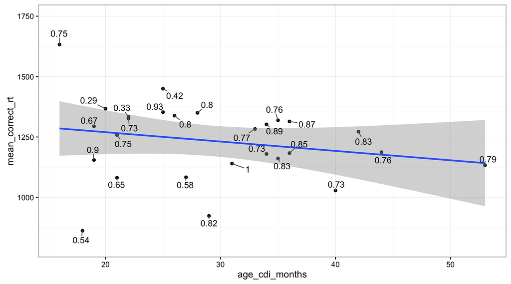

## Model (Lee and Wagenmakers, 2013)

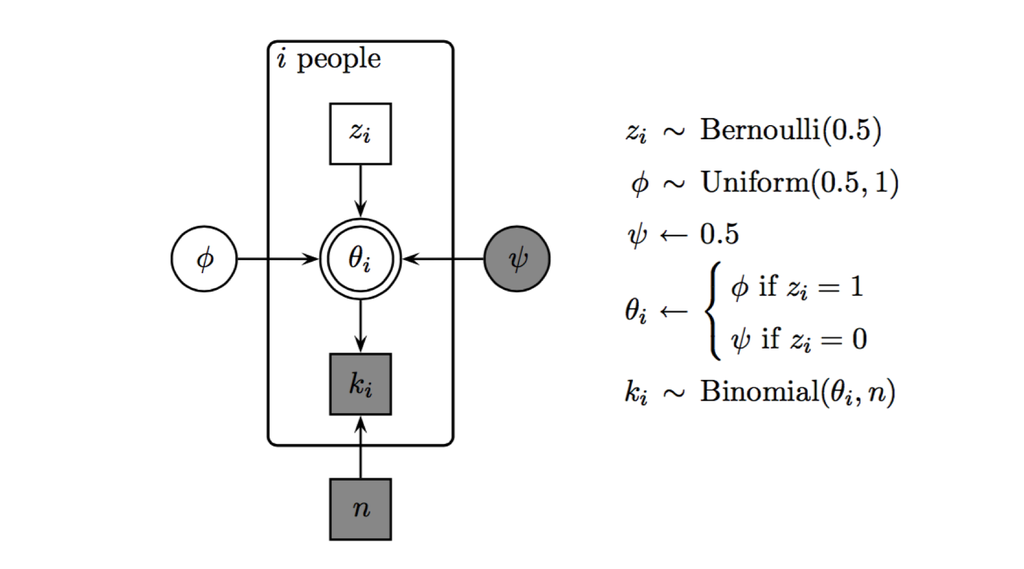

- We assume there are two different groups of people with different probabilities of success, and we want to know something about the overall rate of success and the unobserved group memberships.
- The probability of success on each question for each person is the rate θi. This rate is either ψ, if the person is in the guessing group, or φ if the person is in the knowledge group.
- Which group each person belongs to is determined by a binary indicator variable zi (0: guessing; 1: knowledge)
- We assume each of these indicator variables is equally likely to be 0 or 1 a priori, so they have the prior zi ∼ Bernoulli(1/2).
- For the guessing group, we assume that the rate is ψ = 1/2.
- For the knowledge group, we use a prior where all rate possibilities greater than 0.5 are equally likely, so that φ ∼ Uniform(0.5, 1.)

```r
# Note: I adjusted the model to allow for different number of trials for each participants.
# change n to n[i] in the for loop.
cat('# Exam Scores
model{
  # Each Person Belongs To One Of Two Latent Groups
  for (i in 1:p){
    z[i] ~ dbern(0.5)
  }
  # First Group Guesses
  psi <- 0.5
  # Second Group Has Some Unknown Greater Rate Of Success
  phi ~ dbeta(1,1)I(0.5,1)
  # Data Follow Binomial With Rate Given By Each Persons Group Assignment
  for (i in 1:p){
    theta[i] <- equals(z[i],0)*psi+equals(z[i],1)*phi
    k[i] ~ dbin(theta[i],n[i])
  }
}', file={f<-tempfile()})
```

## Initial values

1. Number of participants
2. Number correct for each participant
3. Number of trials for each participant

```r
p <- nrow(df_correct)                         # number of participants
k <- df_correct$C_T_count                     # number correct for each participant
n <- df_correct$total_trials_shifting         # number of trials for each participant

data <- list("p", "k", "n")                             # data passed on to JAGS
myinits <-  list(list(phi = 0.9, z = round(runif(p)))) # Initial group assignment
```

## Parameters to be monitored

1. φ (the success rate of the knowledge group)
2. z (group membership: knowledge or guessing)

```r
parameters <- c("phi","z")

# get samples
samples <- jags(data, inits=myinits, parameters,
                model.file=f, n.chains=1, n.iter=1000,
                n.burnin=1, n.thin=1, DIC=T)
```

```
##    Graph Size: 238
##
```

```r
# extract values from model
df <- data.frame(phi = samples$BUGSoutput$sims.list$phi,
                 z = samples$BUGSoutput$sims.list$z)

kable(head(df))
```

| phi | z.1 | z.2 | z.3 | z.4 | z.5 | z.6 | z.7 | z.8 | z.9 | z.10 | z.11 | z.12 | z.13 | z.14 | z.15 | z.16 | z.17 | z.18 | z.19 | z.20 | z.21 | z.22 | z.23 | z.24 | z.25 | z.26 | z.27 | z.28 | z.29 |
| --- | --- | --- | --- | --- | --- | --- | --- | --- | --- | --- | --- | --- | --- | --- | --- | --- | --- | --- | --- | --- | --- | --- | --- | --- | --- | --- | --- | --- | --- |
| 0.8375447 | 1 | 1 | 1 | 1 | 1 | 1 | 1 | 0 | 1 | 1 | 0 | 1 | 1 | 0 | 1 | 1 | 1 | 1 | 1 | 1 | 1 | 0 | 0 | 1 | 1 | 1 | 0 | 0 | 0 |
| 0.8136348 | 1 | 1 | 0 | 1 | 1 | 0 | 1 | 0 | 1 | 1 | 1 | 1 | 1 | 0 | 1 | 1 | 1 | 1 | 1 | 1 | 1 | 1 | 0 | 1 | 1 | 1 | 1 | 0 | 0 |
| 0.8166532 | 1 | 1 | 1 | 1 | 1 | 0 | 1 | 0 | 1 | 1 | 1 | 1 | 1 | 1 | 1 | 1 | 1 | 1 | 1 | 1 | 1 | 0 | 0 | 1 | 1 | 1 | 1 | 0 | 0 |
| 0.8086202 | 0 | 1 | 0 | 1 | 1 | 1 | 0 | 0 | 1 | 1 | 0 | 0 | 1 | 0 | 1 | 1 | 1 | 1 | 1 | 1 | 1 | 1 | 0 | 1 | 1 | 1 | 0 | 0 | 0 |
| 0.7764587 | 0 | 1 | 0 | 1 | 1 | 1 | 1 | 0 | 1 | 1 | 1 | 1 | 1 | 0 | 1 | 1 | 1 | 0 | 1 | 1 | 1 | 1 | 0 | 1 | 1 | 1 | 0 | 0 | 0 |
| 0.8152610 | 1 | 1 | 0 | 1 | 1 | 1 | 1 | 0 | 1 | 1 | 0 | 1 | 1 | 1 | 1 | 1 | 1 | 1 | 0 | 1 | 1 | 0 | 0 | 1 | 1 | 1 | 0 | 0 | 0 |

Visualize parameter values

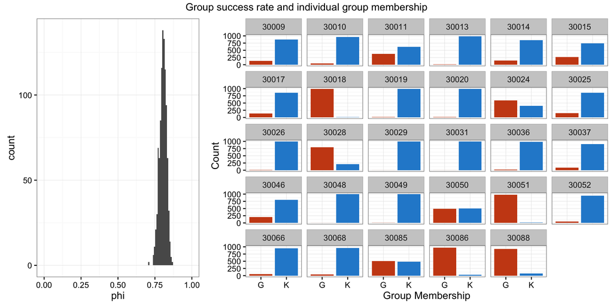

## Flag guessers

Need some criterion for flagging participant as guessing.

| Sub.Num | posterior_mass | C_T_prop | total_trials_shifting |
| --- | --- | --- | --- |
| 30018 | 0.99 | 0.54 | 28 |
| 30028 | 0.79 | 0.58 | 12 |
| 30051 | 0.98 | 0.42 | 12 |
| 30086 | 0.97 | 0.29 | 7 |
| 30088 | 0.92 | 0.33 | 6 |

## Compare to binomial test against chance

| Sub.Num | binom_p | C_T_prop |
| --- | --- | --- |
| 30011 | 0.3125000 | 0.75 |
| 30015 | 0.1445313 | 0.75 |
| 30018 | 0.4252770 | 0.54 |
| 30024 | 0.1661530 | 0.65 |
| 30028 | 0.3872070 | 0.58 |
| 30050 | 0.3437500 | 0.67 |
| 30051 | 0.8061523 | 0.42 |
| 30085 | 0.2539063 | 0.67 |
| 30086 | 0.9375000 | 0.29 |
| 30088 | 0.8906250 | 0.33 |